# Text processing and SVM

**Author**: Vilhelm Stiernstedt  
**Date**: 2018/03/22

### Description

The assignment is focused on text processing and SVM.

Although we are not going to delve into the specifics aspects of text processing, you will have to deal with the specific structures needed for applying Machine Learning to this particular scenario (e.g., document term matrix).

The specific problem we are going to solve is based on a twitter dataset including tweets about US airlines. It includes Twitter data that was scraped from February of 2015 and classified into positive, negative, and neutral, followed by a categorization of the negative reasons (such as "late flight" or "rude service"). Using this dataset we have to identify the sentiment of a given tweet (positive, negative, and neutral) based on its textual content.

In the attachment, you can find one file for the training set annotated with the target variable, one file with the test set, including all the information but the target variable and one file with a submission example.

### Details

This is a multi-class classification task (the target variable to predict is airline_sentiment which can be:

- positive
- negative
- neutral

You must apply SVM to solve the task. You can also apply any of the algorithms we have explained in class to address the task: Regression, Decision Trees, Naive Bayes and KNN...

### Import Libraries

```python
import collections
import matplotlib.pyplot as plt
from mlxtend.classifier import EnsembleVoteClassifier
from mlxtend.classifier import StackingClassifier
import nltk
from nltk import ngrams
from nltk.corpus import stopwords
from nltk.stem.snowball import SnowballStemmer
from nltk.stem import WordNetLemmatizer
from nltk.tokenize import sent_tokenize
from nltk.tokenize import word_tokenize
import numpy as np
import pandas as pd
import seaborn as sns
import re
from scipy.sparse import hstack
from sklearn import metrics
from sklearn import svm
from sklearn.cross_validation import train_test_split
from sklearn.feature_extraction.text import CountVectorizer
from sklearn.feature_extraction.text import TfidfTransformer
from sklearn.linear_model import LogisticRegression
from sklearn.linear_model import SGDClassifier
from sklearn import model_selection
from sklearn.model_selection import cross_val_score
from sklearn.model_selection import GridSearchCV
from sklearn.model_selection import RandomizedSearchCV
from sklearn.multiclass import OneVsRestClassifier
from sklearn.naive_bayes import MultinomialNB
from sklearn.pipeline import Pipeline
from wordcloud import WordCloud, STOPWORDS
import warnings

# download required nltk packages (NB. commented out)
# nltk.download()

# plot settings
%matplotlib inline

# pandas view settings -> see all contents of column
pd.set_option('display.max_colwidth', -1)

# Warning settings -> suppress depreciation warnings
warnings.filterwarnings('ignore')
```

```python
# function to build pipeline with multiple models
# https://github.com/bmurauer/pipelinehelper/blob/master/pipelinehelper.py

from sklearn.base import TransformerMixin, BaseEstimator, ClassifierMixin
from collections import defaultdict
import itertools

class PipelineHelper(BaseEstimator, TransformerMixin, ClassifierMixin):

    def __init__(self, available_models=None, selected_model=None, include_bypass=False):
        self.include_bypass = include_bypass
        self.selected_model = selected_model
        # this is required for the clone operator used in gridsearch
        if type(available_models) == dict:
            self.available_models = available_models
        # this is the case for constructing the helper initially
        else:
            # a string identifier is required for assigning parameters
            self.available_models = {}
            for (key, model) in available_models:
                self.available_models[key] = model

    def generate(self, param_dict={}):
        per_model_parameters = defaultdict(lambda: defaultdict(list))

        # collect parameters for each specified model
        for k, values in param_dict.items():
            model_name = k.split('__')[0]
            param_name = k[len(model_name)+2:]  # might be nested
            if model_name not in self.available_models:
                raise Exception('no such model: {0}'.format(model_name))
            per_model_parameters[model_name][param_name] = values

        ret = []

        # create instance for cartesion product of all available parameters for each model
        for model_name, param_dict in per_model_parameters.items():
            parameter_sets = (dict(zip(param_dict, x)) for x in itertools.product(*param_dict.values()))
            for parameters in parameter_sets:
                ret.append((model_name, parameters))

        # for every model that has no specified parameters, add the default model
        for model_name in self.available_models.keys():
            if model_name not in per_model_parameters:
                ret.append((model_name, dict()))

        # check if the stage is to be bypassed as one configuration
        if self.include_bypass:
            ret.append((None, dict(), True))
        return ret

    def get_params(self, deep=False):
        return {'available_models': self.available_models,
                'selected_model': self.selected_model,
                'include_bypass': self.include_bypass}

    def set_params(self, selected_model, available_models=None, include_bypass=False):
        include_bypass = len(selected_model) == 3 and selected_model[2]

        if available_models:
            self.available_models = available_models

        if selected_model[0] is None and include_bypass:
            self.selected_model = None
            self.include_bypass = True
        else:
            if selected_model[0] not in self.available_models:
                raise Exception('so such model available: {0}'.format(selected_model[0]))
            self.selected_model = self.available_models[selected_model[0]]
            self.selected_model.set_params(**selected_model[1])

    def fit(self, X, y=None):
        if self.selected_model is None and not self.include_bypass:
            raise Exception('no model was set')
        elif self.selected_model is None:
            # print('bypassing model for fitting, returning self')
            return self
        else:
            # print('using model for fitting: ', self.selected_model.__class__.__name__)
            return self.selected_model.fit(X, y)

    def transform(self, X, y=None):
        if self.selected_model is None and not self.include_bypass:
            raise Exception('no model was set')
        elif self.selected_model is None:
            # print('bypassing model for transforming:')
            # print(X[:10])
            return X
        else:
            # print('using model for transforming: ', self.selected_model.__class__.__name__)
            return self.selected_model.transform(X)

    def predict(self, x):
        if self.include_bypass:
            raise Exception('bypassing classifier is not allowed')
        if self.selected_model is None:
            raise Exception('no model was set')
        return self.selected_model.predict(x)
```

### Import Data

```python
# set path to data
data_path = 'assignment_data/'

# load test and train
df_test = pd.read_csv(data_path+'test.csv', sep=',')
df_train = pd.read_csv(data_path+'training.csv', sep=',')

# set index
df_train.set_index('tweet_id', inplace=True)
df_test.set_index('tweet_id', inplace=True)

# create df with target labels
df_labels = pd.DataFrame(df_train.airline_sentiment)
```

### Inspect Data

#### Structure and features

```python
# check dimension of labels
df_labels.shape
```

```
(7000, 1)
```

```python
# check dimension of training data
df_train.shape
```

```
(7000, 15)
```

```python
# check dimension of test data -> more than one column difference!
df_test.shape
```

```
(7640, 13)
```

```python
# check column names and dtypes for training data
df_train.info()
```

```
<class 'pandas.core.frame.DataFrame'>
Float64Index: 7000 entries, 5.6777443767360314e+17 to 5.6925433172514e+17
Data columns (total 15 columns):
airline_sentiment    7000 non-null object
airline              7000 non-null object
name                 7000 non-null object
retweet_count        7000 non-null int64
text                 7000 non-null object
tweet_coord          737 non-null object
tweet_created        6782 non-null object
tweet_location       4813 non-null object
user_timezone        4695 non-null object
Unnamed: 10          183 non-null object
Unnamed: 11          17 non-null object
Unnamed: 12          3 non-null object
Unnamed: 13          1 non-null object
Unnamed: 14          1 non-null object
Unnamed: 15          1 non-null object
dtypes: int64(1), object(14)
memory usage: 875.0+ KB
```

```python
# check column names and dtypes for test data
# -> unamed 9 not in training, but missing unnamed 14 and 15
df_test.info()
```

```
<class 'pandas.core.frame.DataFrame'>
Float64Index: 7640 entries, 5.69936252977451e+17 to 5.69664007864492e+17
Data columns (total 13 columns):
airline           7640 non-null object
name              7640 non-null object
retweet_count     7640 non-null int64
text              7640 non-null object
tweet_coord       796 non-null object
tweet_created     7396 non-null object
tweet_location    5204 non-null object
user_timezone     5150 non-null object
Unnamed: 9        215 non-null object
Unnamed: 10       22 non-null object
Unnamed: 11       5 non-null object
Unnamed: 12       3 non-null object
Unnamed: 13       2 non-null object
dtypes: int64(1), object(12)
memory usage: 835.6+ KB
```

```python
# check df_train
df_train.head(5)
```

| tweet_id | airline_sentiment | airline | name | retweet_count | text | tweet_coord | tweet_created | tweet_location | user_timezone | Unnamed: 10 | Unnamed: 11 | Unnamed: 12 | Unnamed: 13 | Unnamed: 14 | Unnamed: 15 |
| --- | --- | --- | --- | --- | --- | --- | --- | --- | --- | --- | --- | --- | --- | --- | --- |
| 5.677744e+17 | negative | United | kristofurmac | 0 | @united no they were to busy taking to each other and I needed to get to an audition. | NaN | 2015-02-17 11:55:49 -0800 | LA | NaN | NaN | NaN | NaN | NaN | NaN | NaN |
| 5.680326e+17 | neutral | US Airways | MiddleSeatView | 0 | @USAirways if there are empty first class seats on my flight at check in, why wouldn't I be automatically upgraded? | NaN | 2015-02-18 05:01:30 -0800 | Washington, D.C. | Atlantic Time (Canada) | NaN | NaN | NaN | NaN | NaN | NaN |
| 5.684454e+17 | positive | Southwest | Omnicom | 0 | @SouthwestAir @FortuneMagazine Congrats! | NaN | 2015-02-19 08:22:02 -0800 | Worldwide | Atlantic Time (Canada) | NaN | NaN | NaN | NaN | NaN | NaN |
| 5.699783e+17 | neutral | American | DigitalEdMom | 0 | @AmericanAir 3127. Just landed in LIT. | NaN | 2015-02-23 13:53:14 -0800 | Wisconsin | Central Time (US & Canada) | NaN | NaN | NaN | NaN | NaN | NaN |
| 5.697210e+17 | negative | American | OnePoundOne | 0 | @AmericanAir @ArminRosen @ggreenwald Tell that piece of shit to get fucked... I'll fly exclusively with you for life... | NaN | 2015-02-22 20:50:38 -0800 | Chicago | NaN | NaN | NaN | NaN | NaN | NaN | NaN |

```python
# check df_test
df_test.head(5)
```

| tweet_id | airline | name | retweet_count | text | tweet_coord | tweet_created | tweet_location | user_timezone | Unnamed: 9 | Unnamed: 10 | Unnamed: 11 | Unnamed: 12 | Unnamed: 13 |
| --- | --- | --- | --- | --- | --- | --- | --- | --- | --- | --- | --- | --- | --- |
| 5.699363e+17 | Delta | JsLife23 | 0 | @JetBlue but Virgin has wifi 👀 | NaN | 2015-02-23 11:06:06 -0800 | NaN | NaN | NaN | NaN | NaN | NaN | NaN |
| 5.699033e+17 | American | entouchscreen | 0 | @AmericanAir: my brother's flight into DFW was Cancelled Flightled yesterday. Are you flying from ONT to DFW today? | NaN | 2015-02-23 08:55:02 -0800 | Los Angeles | NaN | NaN | NaN | NaN | NaN | NaN |
| 5.695886e+17 | US Airways | evanquinn | 0 | @USAirways has failed me all day long, should I blame it on @AmericanAir ? | NaN | 2015-02-22 12:04:34 -0800 | Newtonville, MA | Pacific Time (US & Canada) | NaN | NaN | NaN | NaN | NaN |
| 5.678433e+17 | Southwest | MikiLuJames | 0 | @SouthwestAir needed my flight info so I can add my rapid rewards to my flight ... First time I have flown with SW - won't do it again #mad | NaN | 2015-02-17 16:29:29 -0800 | NaN | NaN | NaN | NaN | NaN | NaN | NaN |
| 5.701881e+17 | American | wbarkema | 0 | @AmericanAir fortunately the window seat was a no-show. Able to scoot over and create space. | NaN | 2015-02-24 03:46:50 -0800 | NaN | Central Time (US & Canada) | NaN | NaN | NaN | NaN | NaN |

#### Missing values

```python
# missing values for training data -> all unnamed almost 100% NaNs, tweet_coord 90%
df_train.isnull().sum()
```

```
airline_sentiment    0
airline              0
name                 0
retweet_count        0
text                 0
tweet_coord          6263
tweet_created        218
tweet_location       2187
user_timezone        2305
Unnamed: 10          6817
Unnamed: 11          6983
Unnamed: 12          6997
Unnamed: 13          6999
Unnamed: 14          6999
Unnamed: 15          6999
dtype: int64
```

```python
# missing values for training data -> all unnamed almost 100% NaNs, tweet_coord 90%
df_test.isnull().sum()
```

```
airline           0
name              0
retweet_count     0
text              0
tweet_coord       6844
tweet_created     244
tweet_location    2436
user_timezone     2490
Unnamed: 9        7425
Unnamed: 10       7618
Unnamed: 11       7635
Unnamed: 12       7637
Unnamed: 13       7638
dtype: int64
```

### Data Processing

#### Drop irrelevant features

```python
# drop features that's not available in both datasets
df_train.drop(['Unnamed: 14', 'Unnamed: 15'], axis=1, inplace=True)
df_test.drop(['Unnamed: 9'], axis=1, inplace=True)
```

```python
# drop features with extensive NaNs
df_train.drop(['Unnamed: 10', 'Unnamed: 11', 'Unnamed: 12', 'Unnamed: 13', 'tweet_coord'],
              axis=1, inplace=True)

df_test.drop(['Unnamed: 10', 'Unnamed: 11', 'Unnamed: 12', 'Unnamed: 13', 'tweet_coord'],
              axis=1, inplace=True)
```

#### NaN Imputation

##### tweet_created

```python
# tweet_created describe
df_train.tweet_created.describe()
```

```
count     6782
unique    6701
top       [0.0, 0.0]
freq      5
Name: tweet_created, dtype: object
```

```python
# impute NaNs creation date with 'unknown'
df_train.tweet_created.fillna('unknown', inplace=True)
df_test.tweet_created.fillna('unknown', inplace=True)
```

##### tweet_location

```python
# tweet_created describe
df_train.tweet_location.describe()
```

```
count     4813
unique    2218
top       New York, NY
freq      75
Name: tweet_location, dtype: object
```

```python
# impute NaNs tweet_location with 'unknown'
df_train.tweet_location.fillna('unknown', inplace=True)
df_test.tweet_location.fillna('unknown', inplace=True)
```

##### user_timezone

```python
# tweet_created describe
df_train.user_timezone.describe()
```

```
count     4695
unique    240
top       Eastern Time (US & Canada)
freq      1730
Name: user_timezone, dtype: object
```

```python
# check top 10 levels
df_train.user_timezone.value_counts().nlargest(10)
```

```
Eastern Time (US & Canada)     1730
Central Time (US & Canada)     833
Pacific Time (US & Canada)     560
Quito                          336
Atlantic Time (Canada)         239
Mountain Time (US & Canada)    159
Arizona                        110
London                         88
Sydney                         54
Hawaii                         52
Name: user_timezone, dtype: int64
```

```python
# check for most common locations -> we could use location to determine time_zone for NaNs.
df_train.tweet_location.value_counts().nlargest(10)
```

```
unknown            2187
New York, NY       75
Boston, MA         72
USA                70
Washington, DC     60
New York           55
NYC                52
Chicago            51
Los Angeles, CA    48
New York City      41
Name: tweet_location, dtype: int64
```

```python
# for now we impute all NaNs as unknown
df_train.user_timezone.fillna('unknown', inplace=True)
df_test.user_timezone.fillna('unknown', inplace=True)
```

#### Check NaNs again

```python
# for training data
df_train.isnull().sum()
```

```
airline_sentiment    0
airline              0
name                 0
retweet_count        0
text                 0
tweet_created        0
tweet_location       0
user_timezone        0
dtype: int64
```

```python
# for test data
df_test.isnull().sum()
```

```
airline           0
name              0
retweet_count     0
text              0
tweet_created     0
tweet_location    0
user_timezone     0
dtype: int64
```

### Target Analysis

Analyse airline sentiment compared to all features.

```python
df_train.airline_sentiment.value_counts()
```

```
negative    4373
neutral     1498
positive    1129
Name: airline_sentiment, dtype: int64
```

#### airline

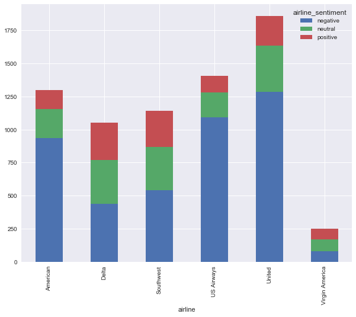

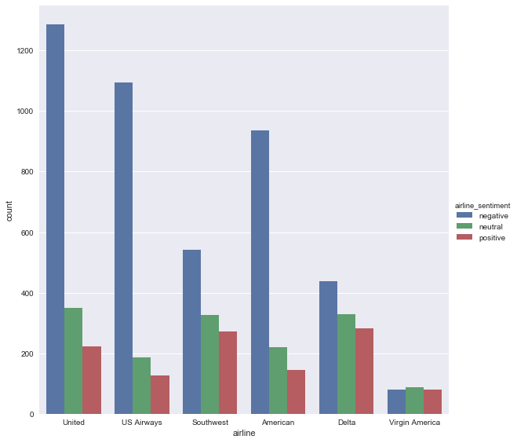

```python
# airline per airline_sentiment
airline_sent = df_train.groupby(['airline', 'airline_sentiment']).airline_sentiment.count().unstack()

# set plot style
sns.set()

# plot 1
airline_sent.plot(kind='bar', stacked=True, figsize=(10, 8))

# plot 2
sns.factorplot(x='airline', hue='airline_sentiment', data=df_train, kind='count', size=8);
```

**Insight**

- US Airways / American most negtative worst
- Southwest / Virgin less data perhaps why better split.

#### tweet_location and user_timezone

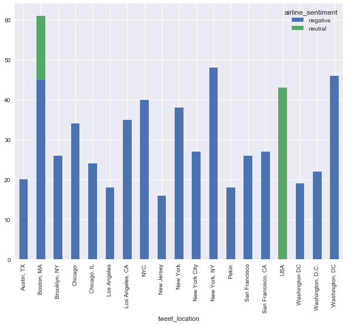

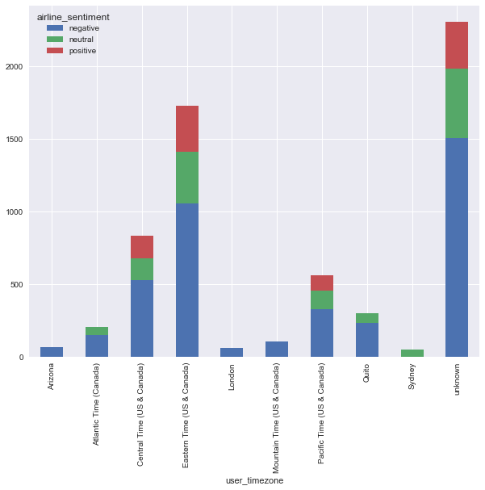

```python
# group data
location_sent = df_train[df_train.tweet_location != 'unknown'].groupby(['tweet_location', 'airline_sentiment']) \
                        .airline_sentiment.count().nlargest(20).unstack()

zone_sent = df_train.groupby(['user_timezone', 'airline_sentiment']) \
                        .airline_sentiment.count().nlargest(20).unstack()


# set plot style
sns.set()

# plot 1
location_sent.plot(kind='bar', stacked=True, figsize=(10, 8));

# plot 2
zone_sent.plot(kind='bar', stacked=True, figsize=(10, 8));
```

**Insight**

- No clear structure between top20 most common user and airline sentiment
- US timezone higher representation of positive sentiment -> loyalty given US airlines perhaps

#### Plot airline_sentiment by retweet_count

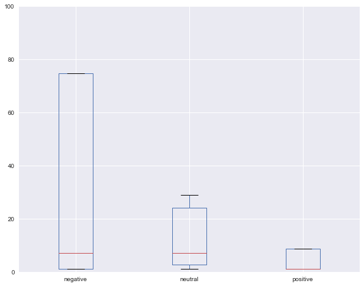

```python
# group data
retweet_sent = df_train.groupby(['retweet_count', 'airline_sentiment']) \
                        .airline_sentiment.count().nlargest(30).unstack()

# set plot style
sns.set()

# plot 1
retweet_sent.plot(kind='box', stacked=True, figsize=(10, 8), ylim=(0, 100));
```

**Insight**

- negative sentiment have some high numbers within 1.5IQR -> bad experiences more shared than good ones perhaps

### WordCloud

#### Negative Sentiment

```python
# subset for negative sentiment
df_cloud = df_train[df_train['airline_sentiment']=='negative']

# subset all words in text based on space
words = ' '.join(df_cloud['text'])

# remove words that contain http, starts with @ or equals RT
cleaned_word = " ".join([word for word in words.split()
                            if 'http' not in word
                                and not word.startswith('@')
                                and word != 'RT'
                            ])
```

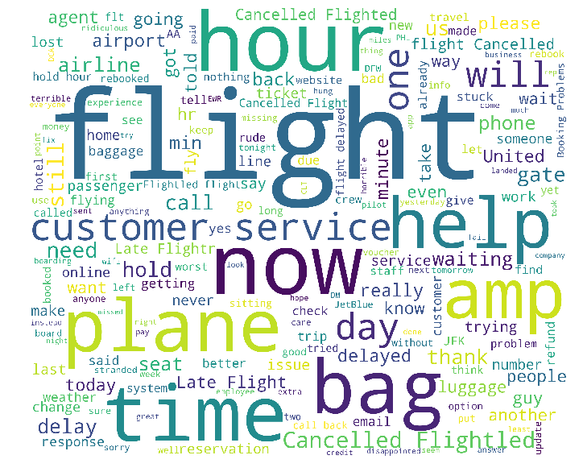

```python
# create wordcloud based on word frequancy
# remove stopwords from cleaned word list
wordcloud = WordCloud(stopwords=STOPWORDS,
                      background_color='white',
                      width=3000,
                      height=2500
                     ).generate(cleaned_word)

# plot wordcloud
plt.figure(1, figsize=(12, 12))
plt.imshow(wordcloud)
plt.axis('off')
plt.show()
```

#### Positive Sentiment

```python
# subset for negative sentiment
df_cloud = df_train[df_train['airline_sentiment']=='positive']

# subset all words in text based on space
words = ' '.join(df_cloud['text'])

# remove words that contain http, starts with @ or equals RT
cleaned_word = " ".join([word for word in words.split()
                            if 'http' not in word
                                and not word.startswith('@')
                                and word != 'RT'
                            ])
```

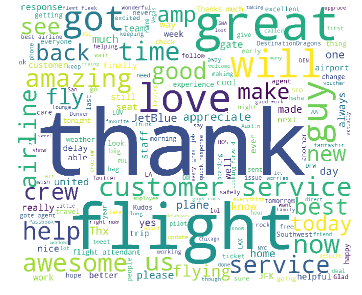

```python
# create wordcloud based on word frequancy
# remove stopwords from cleaned word list
wordcloud = WordCloud(stopwords=STOPWORDS,
                      background_color='white',
                      width=3000,
                      height=2500
                     ).generate(cleaned_word)

# plot wordcloud
plt.figure(1, figsize=(12, 12))
plt.imshow(wordcloud)
plt.axis('off')
plt.show()
```

### Text Analysis

#### normalize text

```python
# define stop words
stop_words = set(stopwords.words('english'))

# define lemmatizer
wordnet_lemmatizer = WordNetLemmatizer()

# create normalization function
def normalizer(tweet):
    only_letters = re.sub("[^a-zA-Z]", " ",tweet) # remove all but letters
    tokens = nltk.word_tokenize(only_letters)[2:] # tokenize words
    lower_case = [l.lower() for l in tokens] # convert to lowercase
    filtered_result = list(filter(lambda l: l not in stop_words, lower_case)) # filter stopwords
    lemmas = [wordnet_lemmatizer.lemmatize(t) for t in filtered_result] # stem words
    return lemmas

# create new feature -> apply function on text
df_train['normalized_txt'] = df_train.text.apply(normalizer)

# view reuslts
df_train[['text','normalized_txt']].head()
```

| tweet_id | text | normalized_txt |
| --- | --- | --- |
| 5.677744e+17 | @united no they were to busy taking to each other and I needed to get to an audition. | [busy, taking, needed, get, audition] |
| 5.680326e+17 | @USAirways if there are empty first class seats on my flight at check in, why wouldn't I be automatically upgraded? | [empty, first, class, seat, flight, check, automatically, upgraded] |
| 5.684454e+17 | @SouthwestAir @FortuneMagazine Congrats! | [congrats] |
| 5.699783e+17 | @AmericanAir 3127. Just landed in LIT. | [landed, lit] |
| 5.697210e+17 | @AmericanAir @ArminRosen @ggreenwald Tell that piece of shit to get fucked... I'll fly exclusively with you for life... | [ggreenwald, tell, piece, shit, get, fucked, fly, exclusively, life] |

#### create sentences

```python
# as words mostly matter in context we'll look at bi-grams instead of just individual tokens
# we define a function that will create sentences by combining tokens from previous output
def ngrams(input_list):
    bigrams = [' '.join(t) for t in list(zip(input_list, input_list[1:]))]
    trigrams = [' '.join(t) for t in list(zip(input_list, input_list[1:], input_list[2:]))]
    return bigrams+trigrams

# create new feature -> apply function on normalized_text
df_train['grams'] = df_train.normalized_txt.apply(ngrams)

# view reuslts
df_train[['grams']].head()
```

| tweet_id | grams |
| --- | --- |
| 5.677744e+17 | [busy taking, taking needed, needed get, get audition, busy taking needed, taking needed get, needed get audition] |
| 5.680326e+17 | [empty first, first class, class seat, seat flight, flight check, check automatically, automatically upgraded, empty first class, first class seat, class seat flight, seat flight check, flight check a… |
| 5.684454e+17 | [] |
| 5.699783e+17 | [landed lit] |
| 5.697210e+17 | [ggreenwald tell, tell piece, piece shit, shit get, get fucked, fucked fly, fly exclusively, exclusively life, ggreenwald tell piece, tell piece shit, piece shit get, shit get fucked, get fucked fly, … |

#### frequency count

```python
# define function to count words
def count_words(input):
    cnt = collections.Counter()
    for row in input:
        for word in row:
            cnt[word] += 1
    return cnt
```

```python
# show 20 most common sentences for negative sentiment
df_train[(df_train.airline_sentiment == 'negative')][['grams']].apply(count_words)['grams'].most_common(20)
```

```
[('customer service', 219),
 ('http co', 190),
 ('cancelled flightled', 184),
 ('late flight', 102),
 ('cancelled flighted', 96),
 ('flight cancelled', 88),
 ('late flightr', 78),
 ('hold hour', 59),
 ('cancelled flight', 57),
 ('flight delayed', 54),
 ('call back', 54),
 ('flightled flight', 54),
 ('flight cancelled flightled', 52),
 ('booking problem', 51),
 ('cancelled flightled flight', 46),
 ('delayed flight', 33),
 ('gate agent', 32),
 ('trying get', 31),
 ('flight booking', 30),
 ('flight booking problem', 30)]
```

```python
# show 20 most common sentences for positive sentiment
df_train[(df_train.airline_sentiment == 'positive')][['grams']].apply(count_words)['grams'].most_common(20)
```

```
[('http co', 118),
 ('customer service', 45),
 ('flight attendant', 14),
 ('gate agent', 10),
 ('quick response', 9),
 ('best airline', 8),
 ('fleet fleek', 8),
 ('fleek http', 8),
 ('fleet fleek http', 8),
 ('fleek http co', 8),
 ('great service', 8),
 ('guy rock', 8),
 ('great flight', 7),
 ('booking problem', 7),
 ('love flying', 7),
 ('good work', 7),
 ('flight thanks', 6),
 ('jet blue', 6),
 ('keep good', 6),
 ('keep good work', 6)]
```

### Text Processing - Round 1

Lets get a model baseline to start with. We'll not modify the text in this round, just execute a mandatory count vectorizing.

#### vectorizing

```python
# define vectorizer without text modifications
count_vectorizer = CountVectorizer(lowercase=False)

# apply vector on text in df_train
vectorized_data = count_vectorizer.fit_transform(df_train.text)
```

### Modelling

#### define targets

```python
# define targets
targets = df_train.airline_sentiment
```

#### split data

```python
# split training data and labels into train and validation 80/20
x_train, x_validation, y_train, y_validation = train_test_split(vectorized_data, targets,
                                                                test_size=0.2, random_state=42)
```

#### SVM

```python
# define svm classifer
clf_svm = SGDClassifier(loss='hinge', penalty='l2', alpha=1e-3,
                        n_iter=5, random_state=42)

# fit model
clf_svm_output = clf_svm.fit(x_train, y_train)

# make predictions
clf_svm_pred = clf_svm_output.predict(x_validation)

# mean accuracy
np.mean(clf_svm_pred == y_validation)
```

```
0.7714285714285715
```

```python
print(metrics.classification_report(y_validation, clf_svm_pred))
```

```
             precision    recall  f1-score   support

   negative       0.82      0.90      0.86       886
    neutral       0.65      0.47      0.55       302
   positive       0.69      0.66      0.67       212

avg / total       0.76      0.77      0.76      1400
```

#### SVM - One Vs All

```python
# define one vs all svm classifer
clf_svm_ova = OneVsRestClassifier(svm.SVC(gamma=0.01, C=100.0,
                                          probability=True,
                                          class_weight='balanced',
                                          kernel='linear'))
# fit model
clf_svm_ova_output = clf_svm_ova.fit(x_train, y_train)

# make predictions
clf_svm_ova_pred = clf_svm_ova_output.predict(x_validation)

# mean accuracy
np.mean(clf_svm_ova_pred == y_validation)
```

```
0.7035714285714286
```

```python
print(metrics.classification_report(y_validation, clf_svm_ova_pred))
```

```
             precision    recall  f1-score   support

   negative       0.83      0.81      0.82       886
    neutral       0.46      0.47      0.46       302
   positive       0.57      0.60      0.59       212

avg / total       0.71      0.70      0.71      1400
```

#### Naive Bayes

```python
# define nb classifier
clf_nb = MultinomialNB()

# fit model
clf_nb_output = clf_nb.fit(x_train, y_train)

# make predictions
clf_nb_pred = clf_nb_output.predict(x_validation)

# mean accuracy
np.mean(clf_nb_pred == y_validation)
```

```
0.7314285714285714
```

```python
print(metrics.classification_report(y_validation, clf_nb_pred))
```

```
             precision    recall  f1-score   support

   negative       0.74      0.95      0.83       886
    neutral       0.62      0.35      0.45       302
   positive       0.78      0.38      0.51       212

avg / total       0.72      0.73      0.70      1400
```

### Text Processing - Round 2

In this round we will use a random search cross validation to explore the best vectorization parameters:

- ngrams range
- stop words
- binary vector (all non zero counts are set to 1)
- lowercase
- max df
- max features

We will also try to optimize our models by chaning the following hyperparamters:

1. SVM
   - alpha
   - loss function
   - l1 ratio (0 = l2)
2. SVM - One vs Rest
   - kernal
   - class weight
   - gamma
   - C
   - probablity
3. Multinomial Navie Bayes
   - alpha

#### split data

```python
# define targets
targets = df_train.airline_sentiment
```

```python
# split training data and labels into train and validation 80/20
x_train, x_validation, y_train, y_validation = train_test_split(df_train.text, targets,
                                                                test_size=0.2, random_state=42)
```

```python
# define pipeline (vectrizer, models)
pipeline = Pipeline([('vect', CountVectorizer()),
                     ('clf', PipelineHelper([
                            ('svm', SGDClassifier()),
                            ('svm_ovr', svm.SVC(decision_function_shape='ovr')),
                            ('multi_nb', MultinomialNB()),
                        ])),
                       ])
```

```python
# define pipline parameters
parameters = {'vect__ngram_range': [(1, 1), (1, 2), (1, 3)],
              'vect__stop_words': ('english', None),
              'vect__binary': (True, False),
              'vect__lowercase': (True, False),
              'vect__max_df': (0.1, 0.25, 0.5, 0.75, 1.0),
              'vect__max_features': (5, 10, 20, 50, 100, None),
              'clf__selected_model': pipeline.named_steps['clf'].generate({
                  'svm__alpha': (0.5, 1e-1, 1e-2, 1e-3, 1e-4, 1e-5, 1e-6),
                  'svm__loss': ('hinge', 'squared_hinge'),
                  'svm__l1_ratio': (0, 0.1, 0.25, 0.5, 0.75, 1.0),
                  'svm_ovr__kernel': ('rbf', 'linear'),
                  'svm_ovr__class_weight': ('balanced', None),
                  'svm_ovr__probability': (True, False),
                  'svm_ovr__C': (1, 10, 25, 50, 100, 200),
                  'svm_ovr__gamma': (0.1, 0.01, 0.001, 'auto'),
                  'multi_nb__alpha': (0.1, 0.25, 0.5, 0.75, 1)
                })
              }
```

```python
# define random search grid with cv
rscv_clf = RandomizedSearchCV(estimator=pipeline, verbose=1,
                                param_distributions=parameters, n_jobs=3,
                                n_iter=100, cv=3, random_state=42)

# fit model based
rscv_clf_mod = rscv_clf.fit(x_train, y_train)

# get best score from CV
rscv_clf_mod.best_score_
```

```
Fitting 3 folds for each of 100 candidates, totalling 300 fits
```

```
[Parallel(n_jobs=3)]: Done  44 tasks      | elapsed:  5.7min
[Parallel(n_jobs=3)]: Done 194 tasks      | elapsed:  9.2min
[Parallel(n_jobs=3)]: Done 300 out of 300 | elapsed: 13.0min finished
```

```
0.76875
```

```python
# make predictions
rscv_clf_pred = rscv_clf_mod.best_estimator_.predict(x_validation)

print(metrics.classification_report(y_validation, rscv_clf_pred))
```

```
             precision    recall  f1-score   support

   negative       0.85      0.90      0.87       886
    neutral       0.63      0.56      0.59       302
   positive       0.72      0.65      0.68       212

avg / total       0.78      0.79      0.78      1400
```

```python
# get parameters for best score from CV
rscv_clf_mod.best_params_
```

```
{'clf__selected_model': ('svm_ovr',
  {'C': 25,
   'class_weight': 'balanced',
   'gamma': 0.001,
   'kernel': 'linear',
   'probability': True}),
 'vect__binary': False,
 'vect__lowercase': True,
 'vect__max_df': 1.0,
 'vect__max_features': None,
 'vect__ngram_range': (1, 2),
 'vect__stop_words': None}
```

### Text Processing - Round 3

In this round we will run a new random grid search and see if stemming (snowballer) or lemmatzing imporves our results.

- stemming: snowball
- lemmatinzing

### Vectorizer w. Snowball Stemmer

```python
# define Snowball stemmer, will not stem stop words
snowball_stemmer = SnowballStemmer("english", ignore_stopwords=True)

# define new vectorizer function with stemmer
class SnowballCountVectorizer(CountVectorizer):
    def build_analyzer(self):
        analyzer = super(SnowballCountVectorizer, self).build_analyzer()
        return lambda doc: ([snowball_stemmer.stem(w) for w in analyzer(doc)])
```

### Vectorizer w. Lemmatizer

```python
# define lemmatizer
lemmatizer = WordNetLemmatizer()

# define new vectorizer function with stemmer
class LemmatizerCountVectorizer(CountVectorizer):
    def build_analyzer(self):
        analyzer = super(LemmatizerCountVectorizer, self).build_analyzer()
        return lambda doc: ([lemmatizer.lemmatize(w) for w in analyzer(doc)])
```

### Modelling

```python
# define pipeline (vectorizer, models)
pipeline = Pipeline([('vect', PipelineHelper([
                            ('counter', CountVectorizer()),
                            ('stemmer', SnowballCountVectorizer()),
                            ('lemmatizer', LemmatizerCountVectorizer()),
                        ])),
                     ('clf', PipelineHelper([
                            ('svm', SGDClassifier()),
                            ('svm_ovr', svm.SVC(decision_function_shape='ovr')),
                            ('multi_nb', MultinomialNB()),
                        ])),
                       ])
```

```python
# define pipline parameters
parameters = {'vect__selected_model': pipeline.named_steps['vect'].generate({
                  'counter__ngram_range': [(1, 1), (1, 2), (1, 3)],
                  'counter__stop_words': ('english', None),
                  'counter__binary': (True, False),
                  'counter__lowercase': (True, False),
                  'counter__max_df': (0.1, 0.25, 0.5, 0.75, 1.0),
                  'counter__max_features': (5, 10, 20, 50, 100, None),
                  'stemmer__ngram_range': [(1, 1), (1, 2), (1, 3)],
                  'stemmer__stop_words': ('english', None),
                  'stemmer__binary': (True, False),
                  'stemmer__lowercase': (True, False),
                  'stemmer__max_df': (0.1, 0.25, 0.5, 0.75, 1.0),
                  'stemmer__max_features': (5, 10, 20, 50, 100, None),
                  'lemmatizer__ngram_range': [(1, 1), (1, 2), (1, 3)],
                  'lemmatizer__stop_words': ('english', None),
                  'lemmatizer__binary': (True, False),
                  'lemmatizer__lowercase': (True, False),
                  'lemmatizer__max_df': (0.1, 0.25, 0.5, 0.75, 1.0),
                  'lemmatizer__max_features': (5, 10, 20, 50, 100, None),
                }),
              'clf__selected_model': pipeline.named_steps['clf'].generate({
                  'svm__alpha': (0.5, 1e-1, 1e-2, 1e-3, 1e-4, 1e-5, 1e-6),
                  'svm__loss': ('hinge', 'squared_hinge'),
                  'svm__l1_ratio': (0, 0.1, 0.25, 0.5, 0.75, 1.0),
                  'svm_ovr__kernel': ('rbf', 'linear'),
                  'svm_ovr__class_weight': ('balanced', None),
                  'svm_ovr__probability': (True, False),
                  'svm_ovr__C': (1, 10, 25, 50, 100, 200),
                  'svm_ovr__gamma': (0.1, 0.01, 0.001, 'auto'),
                  'multi_nb__alpha': (0.1, 0.25, 0.5, 0.75, 1)
                })
              }
```

```python
# define random search grid with cv
rscv_clf = RandomizedSearchCV(estimator=pipeline, verbose=1,
                              param_distributions=parameters, n_jobs=3,
                              n_iter=100, cv=3, random_state=42)

# fit model based
rscv_clf_mod = rscv_clf.fit(x_train, y_train)

# get best score from CV
rscv_clf_mod.best_score_
```

```
Fitting 3 folds for each of 100 candidates, totalling 300 fits
```

```
[Parallel(n_jobs=3)]: Done  44 tasks      | elapsed:  1.3min
[Parallel(n_jobs=3)]: Done 194 tasks      | elapsed: 11.9min
[Parallel(n_jobs=3)]: Done 300 out of 300 | elapsed: 26.8min finished
```

```
0.7682142857142857
```

```python
# make predictions
rscv_clf_pred = rscv_clf_mod.best_estimator_.predict(x_validation)

print(metrics.classification_report(y_validation, rscv_clf_pred))
```

```
             precision    recall  f1-score   support

   negative       0.85      0.90      0.87       886
    neutral       0.63      0.55      0.59       302
   positive       0.71      0.65      0.67       212

avg / total       0.78      0.78      0.78      1400
```

```python
# get parameters for best score from CV
rscv_clf_mod.best_params_
```

```
{'clf__selected_model': ('svm_ovr',
  {'C': 50,
   'class_weight': None,
   'gamma': 0.01,
   'kernel': 'linear',
   'probability': False}),
 'vect__selected_model': ('counter',
  {'binary': False,
   'lowercase': True,
   'max_df': 0.75,
   'max_features': None,
   'ngram_range': (1, 2),
   'stop_words': None})}
```

### Text Processing - Round 4

In this round we will run a new random grid search with 'Term Frequency Inverse Document Frequency' and see if our results improve.

**TF - Term Frequencies** If we count all words in a tweet and divide it by the total words we aviod giving more weightage to longer tweets than shorter ones.

**TF-IDF: Term Frequency times inverse document frequency**  
If we want to reduce the weightage of more common words, we deploy our vectorizer into the TF-IDF transformer, which will assign more weight to less common words.

### Modelling

```python
# define pipeline (vectorizer, models)
pipeline = Pipeline([('vect', PipelineHelper([
                            ('counter', CountVectorizer()),
                            ('stemmer', SnowballCountVectorizer()),
                            ('lemmatizer', LemmatizerCountVectorizer()),
                        ])),
                     ('tf', TfidfTransformer()),
                     ('clf', PipelineHelper([
                            ('svm', SGDClassifier()),
                            ('svm_ovr', svm.SVC(decision_function_shape='ovr')),
                            ('multi_nb', MultinomialNB()),
                        ])),
                       ])
```

```python
# define pipline parameters
parameters = {'vect__selected_model': pipeline.named_steps['vect'].generate({
                  'counter__ngram_range': [(1, 1), (1, 2), (1, 3)],
                  'counter__stop_words': ('english', None),
                  'counter__binary': (True, False),
                  'counter__lowercase': (True, False),
                  'counter__max_df': (0.1, 0.25, 0.5, 0.75, 1.0),
                  'counter__max_features': (5, 10, 20, 50, 100, None),
                  'stemmer__ngram_range': [(1, 1), (1, 2), (1, 3)],
                  'stemmer__stop_words': ('english', None),
                  'stemmer__binary': (True, False),
                  'stemmer__lowercase': (True, False),
                  'stemmer__max_df': (0.1, 0.25, 0.5, 0.75, 1.0),
                  'stemmer__max_features': (5, 10, 20, 50, 100, None),
                  'lemmatizer__ngram_range': [(1, 1), (1, 2), (1, 3)],
                  'lemmatizer__stop_words': ('english', None),
                  'lemmatizer__binary': (True, False),
                  'lemmatizer__lowercase': (True, False),
                  'lemmatizer__max_df': (0.1, 0.25, 0.5, 0.75, 1.0),
                  'lemmatizer__max_features': (5, 10, 20, 50, 100, None),
                }),
              'clf__selected_model': pipeline.named_steps['clf'].generate({
                  'svm__alpha': (0.5, 1e-1, 1e-2, 1e-3, 1e-4, 1e-5, 1e-6),
                  'svm__loss': ('hinge', 'squared_hinge'),
                  'svm__l1_ratio': (0, 0.1, 0.25, 0.5, 0.75, 1.0),
                  'svm_ovr__kernel': ('rbf', 'linear'),
                  'svm_ovr__class_weight': ('balanced', None),
                  'svm_ovr__probability': (True, False),
                  'svm_ovr__C': (1, 10, 25, 50, 100, 200),
                  'svm_ovr__gamma': (0.1, 0.01, 0.001, 'auto'),
                  'multi_nb__alpha': (0.1, 0.25, 0.5, 0.75, 1)
                })
              }
```

```python
# define random search grid with cv
rscv_clf = RandomizedSearchCV(estimator=pipeline, verbose=1,
                              param_distributions=parameters, n_jobs=3,
                              n_iter=100, cv=3, random_state=42)

# fit model based
rscv_clf_mod = rscv_clf.fit(x_train, y_train)

# get best score from CV
rscv_clf_mod.best_score_
```

```
Fitting 3 folds for each of 100 candidates, totalling 300 fits
```

```
[Parallel(n_jobs=3)]: Done  44 tasks      | elapsed:  1.3min
[Parallel(n_jobs=3)]: Done 194 tasks      | elapsed:  8.0min
[Parallel(n_jobs=3)]: Done 300 out of 300 | elapsed: 16.1min finished
```

```
0.78
```

```python
# make predictions
rscv_clf_pred = rscv_clf_mod.best_estimator_.predict(x_validation)

print(metrics.classification_report(y_validation, rscv_clf_pred))
```

```
             precision    recall  f1-score   support

   negative       0.85      0.89      0.87       886
    neutral       0.67      0.57      0.61       302
   positive       0.70      0.68      0.69       212

avg / total       0.79      0.79      0.79      1400
```

```python
# get parameters for best score from CV
rscv_clf_mod.best_params_
```

```
{'clf__selected_model': ('svm_ovr',
  {'C': 25,
   'class_weight': 'balanced',
   'gamma': 0.01,
   'kernel': 'rbf',
   'probability': True}),
 'vect__selected_model': ('stemmer',
  {'binary': False,
   'lowercase': True,
   'max_df': 0.75,
   'max_features': None,
   'ngram_range': (1, 3),
   'stop_words': None})}
```

### Negative Sentiment -> SVM-OVR

Lets define the best model from our random grid search.

```python
# define model
clf_svm_ovr = svm.SVC(kernel='rbf', probability=True,
                      class_weight='balanced',
                      gamma=0.01,
                      C=25,
                      decision_function_shape='ovr')

# define pipeline (vectrizer, tfidtransfomer, model)
txt_clf_svm_ovr_pip = Pipeline([('vect', SnowballCountVectorizer(ngram_range=(1, 3), max_df=0.75)),
                           ('tfidf', TfidfTransformer()),
                           ('clf', clf_svm_ovr)])

# fit model as per pipeline
txt_clf_svm_ovr_mod = txt_clf_svm_ovr_pip.fit(x_train, y_train)

# make predictions
txt_clf_svm_ovr_pred = txt_clf_svm_ovr_mod.predict(x_validation)

# mean accuracy
np.mean(txt_clf_svm_ovr_pred == y_validation)
```

```
0.7914285714285715
```

```python
print(metrics.classification_report(y_validation, txt_clf_svm_ovr_pred))
```

```
             precision    recall  f1-score   support

   negative       0.85      0.89      0.87       886
    neutral       0.67      0.57      0.61       302
   positive       0.70      0.68      0.69       212

avg / total       0.79      0.79      0.79      1400
```

### Positive Sentiment -> Navie Bayes

```python
# define model
clf_nb = MultinomialNB()

# define pipeline (vectrizer, tfidtransfomer, model)
txt_clf_nb_pip_1 = Pipeline([('vect', SnowballCountVectorizer(stop_words='english')),
                             ('tfidf', TfidfTransformer()),
                             ('clf', clf_nb)])

# fit model as per pipeline
txt_clf_nb_mod_1 = txt_clf_nb_pip_1.fit(x_train, y_train)

# make predictions
txt_clf_nb_pred_1 = txt_clf_nb_mod_1.predict(x_validation)

# mean accuracy
np.mean(txt_clf_nb_pred_1 == y_validation)
```

```
0.6671428571428571
```

```python
print(metrics.classification_report(y_validation, txt_clf_nb_pred_1))
```

```
             precision    recall  f1-score   support

   negative       0.66      1.00      0.79       886
    neutral       0.86      0.10      0.18       302
   positive       0.95      0.08      0.16       212

avg / total       0.75      0.67      0.57      1400
```

### Neutral Sentiment -> Navie Bayes

```python
# define model
clf_nb = MultinomialNB()

# define pipeline (vectrizer, tfidtransfomer, model)
txt_clf_nb_pip_2 = Pipeline([('vect', SnowballCountVectorizer(stop_words='english', ngram_range=(1,2))),
                             ('tfidf', TfidfTransformer()),
                             ('clf', clf_nb)])

# fit model as per pipeline
txt_clf_nb_mod_2 = txt_clf_nb_pip_2.fit(x_train, y_train)

# make predictions
txt_clf_nb_pred_2 = txt_clf_nb_mod_2.predict(x_validation)

# mean accuracy
np.mean(txt_clf_nb_pred_2 == y_validation)
```

```
0.6564285714285715
```

```python
print(metrics.classification_report(y_validation, txt_clf_nb_pred_2))
```

```
             precision    recall  f1-score   support

   negative       0.65      1.00      0.79       886
    neutral       0.95      0.07      0.12       302
   positive       0.76      0.06      0.11       212

avg / total       0.73      0.66      0.54      1400
```

### Conclusion

We will now try to combine these models to get the best possible classifer. We will try:

- stacking
- ensamble

### Stacking Models

```python
# Factorize train_labels
target_labels = pd.factorize(df_train.airline_sentiment)[0]
```

```python
# Convert to numpy arrays
target_labels_np = np.array(target_labels)
train_data_np = np.array(df_train.text)
test_data_np = np.array(df_test.text)
```

```python
# Stacking classifer
# Define the method for meta classifing
lr = LogisticRegression()
clf1 = txt_clf_svm_ovr_pip
clf2 = txt_clf_nb_pip_1
clf3 = txt_clf_nb_pip_2

# Define stacking classifier
sclf = StackingClassifier(classifiers=[clf1, clf2, clf3],
                          meta_classifier=lr,
                          use_probas=True,
                          average_probas=False)

# Define name of models and stack classifier
labels = ['SVM_OVR_Neg', 'Multi_NB_Pos', 'Multi_NB_Neu', 'LRStack']

# Define classifer list
clf_list = [clf1, clf2, clf3, sclf]
```

```python
# Assing empty lists for cross validation mean scores and std
clf_cv_mean = []
clf_cv_std = []

# Cross validate each model and plot average score
for clf, label in zip(clf_list, labels):

    scores = cross_val_score(clf, train_data_np, target_labels_np, cv=3)
    print("Accuracy: %.3f (+/- %.3f) [%s]" %(scores.mean(), scores.std(), label))
    clf_cv_mean.append(scores.mean())
    clf_cv_std.append(scores.std())
```

```
Accuracy: 0.780 (+/- 0.007) [SVM_OVR_Neg]
Accuracy: 0.658 (+/- 0.002) [Multi_NB_Pos]
Accuracy: 0.649 (+/- 0.000) [Multi_NB_Neu]
Accuracy: 0.780 (+/- 0.001) [LRStack]
```

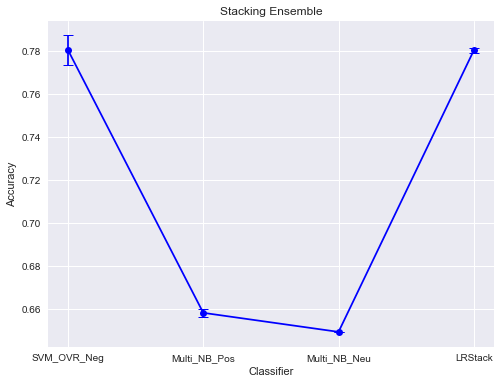

```python
# Plot the accurancy of the different models
plt.figure(figsize=(8, 6))

(_, caps, _) = plt.errorbar(range(4), clf_cv_mean, yerr=clf_cv_std, c='blue', fmt='-o', capsize=5)

for cap in caps:
    cap.set_markeredgewidth(1)

plt.xticks(range(4), ['SVM_OVR_Neg', 'Multi_NB_Pos', 'Multi_NB_Neu', 'LRStack'])
plt.ylabel('Accuracy'); plt.xlabel('Classifier'); plt.title('Stacking Ensemble');
plt.show()
```

### Ensemble Models

```python
# Define Ensemble classifers
clf1 = txt_clf_svm_ovr_pip
clf2 = txt_clf_nb_pip_1
clf3 = txt_clf_nb_pip_2
eclf = EnsembleVoteClassifier(clfs=[clf1, clf2, clf3], voting='soft', weights=[0.5,0.2,0.2])

# Define name of models and stack classifier
labels = ['SVM_OVR_Neg', 'Multi_NB_Pos', 'Multi_NB_Neu', 'Ensemble']

# Define classifer list
clf_list = [clf1, clf2, clf3, eclf]
```

```python
# Cross validate each model and plot average score
for clf, label in zip(clf_list, labels):

    scores = model_selection.cross_val_score(clf, train_data_np, target_labels_np, cv=3)
    print("Accuracy: %0.3f (+/- %0.3f) [%s]"
          % (scores.mean(), scores.std(), label))
```

```
Accuracy: 0.780 (+/- 0.007) [SVM_OVR_Neg]
Accuracy: 0.658 (+/- 0.002) [Multi_NB_Pos]
Accuracy: 0.649 (+/- 0.000) [Multi_NB_Neu]
Accuracy: 0.776 (+/- 0.004) [Ensemble]
```

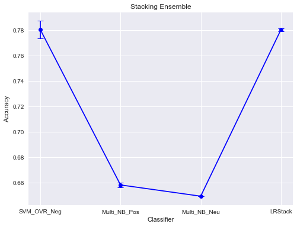

```python
# Plot the accurancy of the different models
plt.figure(figsize=(8, 6))

(_, caps, _) = plt.errorbar(range(4), clf_cv_mean, yerr=clf_cv_std, c='blue', fmt='-o', capsize=5)

for cap in caps:
    cap.set_markeredgewidth(1)

plt.xticks(range(4), ['SVM_OVR_Neg', 'Multi_NB_Pos', 'Multi_NB_Neu', 'LRStack'])
plt.ylabel('Accuracy'); plt.xlabel('Classifier'); plt.title('Stacking Ensemble');
plt.show()
```

### Final Model

Unfortuantely we did not mange to combine our three induvidually good models to create better model. Probably as the negative class is over represented and the other models fail at doing decent predictions of this class. We will use the svm - ovr model for the final prediction of the test dataset.

```python
# Fit model
txt_clf_svm_ovr_pip.fit(train_data_np, target_labels_np)
```

```
Pipeline(memory=None,
     steps=[('vect', SnowballCountVectorizer(analyzer='word', binary=False, decode_error='strict',
            dtype=<class 'numpy.int64'>, encoding='utf-8', input='content',
            lowercase=True, max_df=0.75, max_features=None, min_df=1,
            ngram_range=(1, 3), preprocessor=None, stop_word...',
  max_iter=-1, probability=True, random_state=None, shrinking=True,
  tol=0.001, verbose=False))])
```

```python
# Make predictions for test data, input into new df
final_predictions = pd.DataFrame(txt_clf_svm_ovr_pip.predict(test_data_np))
```

### Submission

Write prediction to submission.csv

```python
# New df
submission = pd.DataFrame()

# Import id from test_data index
submission['tweet_id'] = df_test.index

# import status_group predictions
submission['airline_sentiment'] = final_predictions

# convert numerical to description
submission.loc[submission.airline_sentiment == 0, 'airline_sentiment'] = 'negative'
submission.loc[submission.airline_sentiment == 1, 'airline_sentiment'] = 'neutral'
submission.loc[submission.airline_sentiment == 2, 'airline_sentiment'] = 'positive'
```

```python
# Preview
submission.head()
```

|  | tweet_id | airline_sentiment |
| --- | --- | --- |
| 0 | 5.699363e+17 | positive |
| 1 | 5.699033e+17 | negative |
| 2 | 5.695886e+17 | negative |
| 3 | 5.678433e+17 | neutral |
| 4 | 5.701881e+17 | negative |

```python
# Write submission to csv
submission.to_csv('submission_final.csv', sep=',', index=False)
```

### Final Remarks

Other than trying to construct a combined model that would correctly unite the three models that seem to classify at least one class good, we could also try to build a model that looks at other features than the text such as tweet location and more importantly airline, as it seem to be some relationships. We could do so by using a ensamble or stacking model that allow different models to use different features from the training set. As of now we concluded that our model is reasonable good at highlightning negative sentiment, which should be the most important for an airline. Given we cross validated the model we hope that it should not be overfitted and we can expect a total accurancy just below 80%.